# El bambú

Ponce Diego Norma Gabriela

7 de marzo 2021

Problema

¿por qué si el bambú es una materia biodegradable y con perspectivas de que con él es fácil sustituir cualquier tipo de material, no se produce tantos bienes?

Lo natural

Las materias primas necesarias para producir un bien, en este caso para el bambú son

• Clima tropical

• Tierra

• Sol

• Agua

• Semilla

Valor de uso

El valor de uso es el valor que tiene un objeto para satisfacer necesidades, la utilidad que tiene.

¿para qué es útil el bambú?

Conforme a las propiedades del cuerpo del bambú y sus características encontramos muchas formas en las que podemos utilizarlo, mencionaremos las principales industrias en las que tiene utilidad para satisfacer necesidades

• Industria de la madrea

• Industria del papel

• Industria textil

• Industria bioenergética

• Industria de alimentos y bebidas

• Industria automotriz

• Industria agrícola

Valor de cambio

Su valor de cambio se determina con el trabajo socialmente determinado requerido para producir cierta mercancía que generalmente se expresa en forma cuantitativa y se encuentra siempre por encima o debajo del precio El bambú requiere de plantar la semilla y cuidarla aproximadamente 5 meses seguidos de ahí procede dejarla crecer durante 4 años (un periodo relativamente corto en comparación con otros tipos de plantas o árboles que es su principal comparación) En el momento del intercambio esta planta se tendría que cambiar por una con e mismo trabajo socialmente requerido para su producción o bien algo equivalente

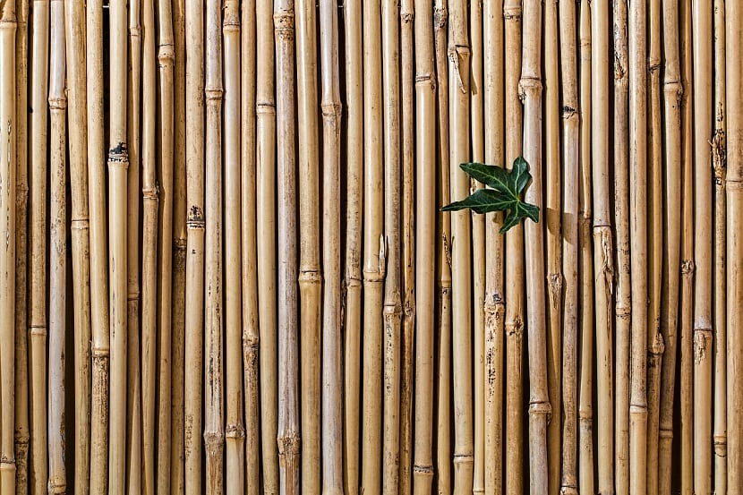

https://www.jardineriaon.com/bambu.html

## Bibliografía

1. 1000 productos hechos de bambú. (2015, 24 diciembre). Guada Bamboo. https://www.guaduabambu.com.co/blog/productos-hechos-de-bambu
2. Produccion de Bambú Cap 241. (2015, 17 noviembre). [Vídeo]. YouTube. https://www.youtube.com/watch?v=G96p1CffkT8